# Introduction to ggvis

June 25, 2015

## What you need:

The following packages will be used in this talk:

```r
library(dplyr)
library(ggvis)
library(ggplot2)
library(shiny)
library(splines)
```

- RStudio
- script file `ggvis-talk.code.R` from `datascience.vegas` site

## An Introductory example: ggplot2

```r
ggplot(mtcars, aes(x = disp, y = mpg)) +
  geom_point(color = "blue") +
  geom_smooth(color = "darkblue", size = 1)
```

```
geom_smooth: method="auto" and size of largest group is <1000, so using loess. Use 'method = x' to change the smoothing method.
```

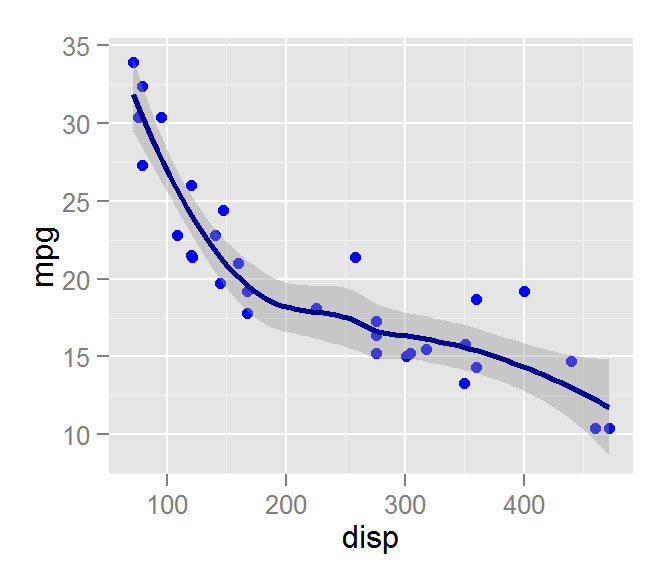

## Same example in ggvis

```r
mtcars %>% ggvis(x = ~ disp, y = ~ mpg) %>%
  layer_points(stroke := "blue", size := 50) %>%
  layer_smooths(stroke := "darkblue",
                strokeWidth := 3, se = TRUE)
```

## What is ggvis?

- an R package for web-based graphics
- based on the Vega visualization system in JavaScript
- brought to you by the lead developers of `ggplot2`.

`ggvis` is a fusion of:

- the grammar of graphics from `ggplot2`
- reactive programming from `shiny`
- data transformation pipelines from `dplyr`

## What is ggvis? (cont.)

Each `ggvis` function takes a visualization object as input and returns a modified visualization as output.

```
p <- InsectSprays %>% ggvis(x = ~ spray, y = ~ count)
p <- layer_boxplots(p, fill = ~ spray)
p
```

## Contrasts between ggvis and ggplot2

| ggvis | ggplot2 |
| --- | --- |
| web graphics | presentation graphics |
| static or reactive graphics | static graphics |
| evolving | mature |
| rendering: Vega visualization (JS) | rendering: R grid graphics |

## Basic constructs in ggvis

- fundamental building block in `ggvis` is the *mark*
- draws a specific type of geometric object
- a *layer* draws graphical content in a `ggvis`
- simple layers (wrappers for marks)
- compound layers (marks + statistical/data transformation)
- `compute_*()` functions perform statistical transformations
- `scale_*()` functions modify how data values are mapped to the visual space (relative to defaults)
- `input_*()` functions generate interactive objects such as checkboxes, sliders or input boxes.

## Syntax

- symbol `~` means that the variable to be assigned should be taken from the current data object;
- symbol `=` means that the value assigned to a mark is to be mapped to a *scaled value* (i.e., in data units);
- the symbol `:=` means that the value assigned to a mark is set to an *unscaled value* independent of data units.

More accurately, `~` means "capture the expression for later evaluation in the context of the data".

**Warning**: Using `:=` when `=` is appropriate, or vice versa, can produce *very* different behavior.

## Grouping

- in `ggplot2`, grouping was handled with a `group` aesthetic
- in `ggvis`, grouping is a data transformation
- use `group_by()` in the data pipeline

```r
InsectSprays %>% group_by(spray) %>%
                 compute_boxplot(~ count)
```

```
Source: local data frame [6 x 7]
Groups: spray

  spray min_ lower_ median_ upper_ max_ outliers_
1     A    7  11.50    14.0  17.75   23  <dbl[0]>
2     B    7  12.50    16.5  17.50   21  <dbl[0]>
3     C    0   1.00     1.5   3.00    4  <dbl[1]>
4     D    2   3.75     5.0   5.00    6  <dbl[1]>
5     E    1   2.75     3.0   5.00    6  <dbl[0]>
6     F    9  12.50    15.0  22.50   26  <dbl[0]>
```

## Marks and properties

- seven basic marks in `ggvis`
- marks are endowed with properties
- each property has one or more values.
- this hierarchy increases the flexibility of `ggvis`

## Basic marks and simple layers

| Mark | Layer | related ggplot2 geoms |
| --- | --- | --- |
| `mark_area()` | `layer_areas()` | `geom_ribbon(), geom_area()` |
| `mark_path()` | `layer_paths()` | `geom_path(), geom_line()` |
| `mark_rect()` | `layer_rects()` | `geom_rect(), geom_bar(), geom_tile()` |
| `mark_point()` | `layer_points()` | `geom_point()` |
| `mark_text()` | `layer_text()` | `geom_text()` |
| `mark_arc()` | `layer_arcs()` | (draws arcs/curves) |
| `mark_image()` | `layer_images()` | (imports image from file/URL) |

## compute_*() functions

- perform statistical transformations on the input data
- `compute_*()` functions are data transformations
- results can be passed along the data pipeline
- illustrates the enriched types of (hierarchical) data structures supported by `ggvis`

## `compute_*()` functions (cont.)

- `compute_align`: align positions using length
- `compute_bin`: bin data along a continuous variable
- `compute_boxplot`: compute values needed for a boxplot
- `compute_count`: count data at fixed numeric locations
- `compute_density`: compute kernel density estimate
- `compute_model_prediction`: compute predicted values from a statistical model of one variable
- `compute_smooth`: compute predicted values for a loess model
- `compute_stack`: compute inputs for stacked bar/area charts
- `compute_tabulate`: count data at each level of a factor or categorical variable

## Compound layers

| Function | Composition |
| --- | --- |
| `layer_bars()` | `layer_rects() + compute_tabulate()` |
| `layer_boxplots()` | `compute_boxplot() + several simple layers` |
| `layer_densities()` | `compute_density() + layer_paths()` |
| `layer_freqpolys()` | `compute_bin() + layer_paths()` |
| `layer_histograms()` | `compute_bin() + layer_rects()` |
| `layer_lines()` | `dplyr::arrange() + layer_paths()` |
| `layer_model_predictions()` | `compute_model_prediction() + layer_lines()` |
| `layer_smooths()` | `compute_smooth() + layer_areas() + layer_lines()` |

## Examples

## Use of compute_ functions

```r
mpg1 <- mpg %>% mutate(Cyl = factor(cyl))
mpg1 %>% compute_tabulate(~ Cyl)  # cyl coerced to factor
```

[output not shown]

```r
mtcars %>%   # bs() comes from splines package [B-spline]
  compute_model_prediction(mpg ~ bs(disp, 5), model = "lm") %>%
  head(3)
```

```
     pred_    resp_
1 71.10000 33.03321
2 76.17468 31.32620
3 81.24937 29.81609
```

## compute_ functions (cont.)

```r
mpg %>% compute_count(~ cyl)   # cyl is numeric
```

```
  count_ x_
1     81  4
2      4  5
3     79  6
4     70  8
```

```r
# Compute counts for stacked bar chart
hec <- as.data.frame(xtabs(Freq ~ Hair + Eye, HairEyeColor))
hec %>% compute_stack(stack_var = ~Freq, group_var = ~Hair)
```

```
Source: local data frame [16 x 6]

    Hair   Eye Freq group__ stack_upr_ stack_lwr_
1  Black Brown   68   Black         68          0
2  Brown Brown  119   Brown        119          0
3    Red Brown   26     Red         26          0
4  Blond Brown    7   Blond          7          0
5  Black  Blue   20   Black         88         68
6  Brown  Blue   84   Brown        203        119
7    Red  Blue   17     Red         43         26
8  Blond  Blue   94   Blond        101          7
9  Black Hazel   15   Black        103         88
10 Brown Hazel   54   Brown        257        203
11   Red Hazel   14     Red         57         43
12 Blond Hazel   10   Blond        111        101
13 Black Green    5   Black        108        103
14 Brown Green   29   Brown        286        257
15   Red Green   14     Red         71         57
16 Blond Green   16   Blond        127        111
```

## Examples with simple layers

## layer_points()

```r
# Remove 5 cylinder cars
filter(mpg1, cyl != 5) %>%
  ggvis(x = ~ displ, y = ~ hwy, fill = ~ Cyl) %>%
  layer_points(stroke := "black", strokeWidth := 1,
               size := 100)
```

## layer_paths()

```r
DF0 <- data.frame(x = c(2, 5, 6, 8, 7, 4),
                 y = c(3, 6, 9, 11, 7, 2))
p <- DF0 %>% ggvis(x = ~ x, y = ~ y)
p %>% layer_paths()     # path
```

## layer_paths() : polygon

```r
# layer_path() + fill property = polygon
p %>% layer_paths(fill := "blue", fillOpacity := 0.5)
```

## layer_text()

```r
# Add state names as a variable to USArrests
# Note that the text property is always unscaled
usarrests <- data.frame(state = rownames(USArrests), USArrests,
                        stringsAsFactors = FALSE)
usarrests %>% ggvis(x = ~ UrbanPop, y = ~ Assault) %>%
              layer_text(text := ~ state)
```

## Examples: compound layers

## Histogram

```r
mpg %>% ggvis(x = ~ hwy) %>%
        layer_histograms(fill := "blue", width = 2.5)
```

## Groupwise density estimates

```r
filter(mpg1, cyl != 5) %>%
    group_by(Cyl) %>%   # groupwise density estimates
    ggvis(x = ~ displ, fill = ~ Cyl) %>%
    layer_densities()
```

## Box plots

```r
InsectSprays %>% ggvis(x = ~ spray, y = ~ count) %>%
                 layer_boxplots(fill = ~ spray)
```

## Lines

Compare this to the earlier plot using `layer_paths()`.

```r
DF0 %>% ggvis(~ x, ~ y) %>% layer_lines()
```

## Multiple model fits

```r
suppressWarnings(filter(mpg, cyl != 5) %>%
   ggvis(x = ~ displ, y = ~ hwy) %>%
   layer_points(fillOpacity := 0.3) %>%
   layer_smooths(se = FALSE, stroke := "blue") %>%
   layer_model_predictions(model = "lm", stroke := "black") %>%
   layer_model_predictions(model = "MASS::rlm", stroke := "red"))
```

```
Guessing formula = hwy ~ displ
Guessing formula = hwy ~ displ
```

## Side note re positioning of mark properties

Mark properties set/mapped inside `ggvis()` are intended to be global—i.e., they are meant to persist across layers.

Mark properties that are meant to be local to an individual layer are defined as part of the specification of that layer.

```
mpg %>%
  ggvis(x = ~ cyl, y = ~ hwy) %>%  # global assignments
  layer_boxplots(width = 0.5, fill = ~ factor(cyl)) # local assignments
```

## Data pipeline + visualization

## Smoothers

```r
filter(mpg1, Cyl != 5) %>%
    ggvis(x = ~ displ, y = ~ hwy) %>%
    layer_smooths(strokeWidth := 3, se = TRUE) %>%  # overall
    group_by(Cyl) %>%
    layer_points(fill = ~ Cyl, stroke = ~ Cyl,
                   fillOpacity := 0.4, strokeOpacity := 0.7) %>%
    layer_smooths(stroke = ~ Cyl)
```

## Interactivity

## Interactivity functions in ggvis

- `input_checkbox()`: creates a single-item checkbox
- `input_checkboxgroup()`: creates a multi-item checkbox group
- `input_numeric()`: creates an interactive box for numeric input
- `input_radiobuttons()`: creates a box composed of radio buttons
- `input_select()`: creates a multiple selection box
- `input_slider()`: creates an interactive slider
- `input_text()`: creates an interactive text box

## Example 1: Histogram with slider

Copy/paste code from script file to run interactively:

```
slider_box <- input_slider(0.5, 10, value = 3,
                           step = 0.5, label = "Bin width")
mpg %>% ggvis(x = ~ hwy) %>%
        layer_histograms(width = slider_box, fill := "darkorange")
```

## Example 2: Loess smooth with slider

```
# input_ function defined as a property 'value'
mpg %>% ggvis(x = ~ displ, y = ~ hwy) %>%
        layer_points(fillOpacity := 0.3) %>%
        layer_smooths(stroke := "blue", strokeWidth := 2,
                      span = input_slider(0.2, 1,
                               value = 0.5, label = "Span" ))
```

## Tooltips

- display information about the data associated with a geometric object

The game is to:

- write a function that determines how the tooltip behaves;
- call it in a layer function with additional arguments concerning tooltips.

## Example: Display data values

```
# Function to specify what is to be visualized when a
# point is hovered over
all_values <- function(x)
{
    if(is.null(x)) return(NULL)
    paste0(names(x), ": ", format(x), collapse = "<br />")
}

mtcars %>% ggvis(x = ~ wt, y = ~ mpg) %>%
           layer_points(fill.hover := "red") %>%
           add_tooltip(all_values, "hover")
```

## Shiny integration

## ggvis and shiny

- can use shiny reactives to create a ggvis object
- can embed ggvis graphics in a Shiny app
- In functional reactive programming, a reactive can input values from another reactive, thus producing a dependency chain
- the reactives persist
- when the value of an ancestor node changes, all descendants are recomputed

## ggvis where data is reactive

```
dat <- data.frame(time = 1:10, value = runif(10))

# Create a reactive that returns a data frame, adding a new
# row every 0.5 seconds
ddat <- reactive({
  invalidateLater(500, NULL)
  dat$time <<- c(dat$time[-1], dat$time[length(dat$time)] + 1)
  dat$value <<- c(dat$value[-1], runif(1))
  dat
})
ddat %>% ggvis(x = ~time, y = ~value, key := ~time) %>%
  layer_points() %>%
  layer_paths()
```

## Topics not covered

- scales and axes specification
- legends
- Shiny apps with embedded ggvis

## Resources

- `ggvis` vignettes and demos
- http://ggvis.rstudio.com
- Winston Chang's talk at useR!14 (YouTube)
- http://cdn.oreillystatic.com/en/assets/1/event/120/ggvis_%20Interactive,%20intuitive%20graphics%20in%20R%20Presentation.pdf
- Google search on ggvis!!